# Análisis de Minería de Datos - Detección de Estrés

Isabel Cantero

```r
library(ggplot2)
library(gridExtra)
library(dplyr)
library(tidyverse)
library(reshape2)
library(caret)
library(factoextra)
```

# 1. Carga de Datos

```r
df <- read.csv("stress.csv")

dim(df)
```

```
## [1] 773  22
```

```r
str(df)
```

```
## 'data.frame':    773 obs. of  22 variables:
##  $ Age                : int  30 35 40 35 29 45 32 37 50 40 ...
##  $ Gender             : chr  "Male" "Female" "Male" "Male" ...
##  $ Occupation         : chr  "Software Engineer" "Marketing Manager" "Data Scientist" "Software Engineer" ...
##  $ Marital_Status     : chr  "Single" "Married" "Divorced" "Single" ...
##  $ Sleep_Duration     : num  7 6 7 7 8 6 7 7.5 5.5 6 ...
##  $ Sleep_Quality      : num  4 3 4 4 5 3 4 4 2 3 ...
##  $ Wake_Up_Time       : chr  "7:00 AM" "6:00 AM" "7:00 AM" "7:00 AM" ...
##  $ Bed_Time           : chr  "10:00 PM" "11:00 PM" "10:00 PM" "10:00 PM" ...
##  $ Physical_Activity  : num  2 1 2 2 3 2 1 2.5 2 3 ...
##  $ Screen_Time        : num  4 3 4 4 2 4 6 3.5 8 4.5 ...
##  $ Caffeine_Intake    : int  1 0 1 1 1 2 3 2 3 2 ...
##  $ Alcohol_Intake     : int  0 1 0 0 0 1 0 0 2 0 ...
##  $ Smoking_Habit      : chr  "No" "No" "No" "No" ...
##  $ Work_Hours         : int  8 9 8 8 7 10 9 8 12 9 ...
##  $ Travel_Time        : num  1 2 1 1 1 2 0.5 1.5 2 1 ...
##  $ Social_Interactions: int  5 3 5 5 4 3 2 5 2 4 ...
##  $ Meditation_Practice: chr  "Yes" "No" "Yes" "Yes" ...
##  $ Exercise_Type      : chr  "Cardio" "Yoga" "Strength Training" "Cardio" ...
##  $ Blood_Pressure     : int  120 110 130 120 110 130 120 140 150 125 ...
##  $ Cholesterol_Level  : int  180 160 200 180 180 220 190 210 240 200 ...
##  $ Blood_Sugar_Level  : int  90 80 100 90 90 110 85 100 130 105 ...
##  $ Stress_Detection   : chr  "Low" "Medium" "High" "Low" ...
```

```r
head(df)
```

```
##   Age Gender        Occupation Marital_Status Sleep_Duration Sleep_Quality
## 1  30   Male Software Engineer         Single              7             4
## 2  35 Female Marketing Manager        Married              6             3
## 3  40   Male    Data Scientist       Divorced              7             4
## 4  35   Male Software Engineer         Single              7             4
## 5  29 Female           Teacher         Single              8             5
## 6  45   Male            Doctor        Married              6             3
##   Wake_Up_Time Bed_Time Physical_Activity Screen_Time Caffeine_Intake
## 1      7:00 AM 10:00 PM                 2           4               1
## 2      6:00 AM 11:00 PM                 1           3               0
## 3      7:00 AM 10:00 PM                 2           4               1
## 4      7:00 AM 10:00 PM                 2           4               1
## 5      6:30 AM 10:30 PM                 3           2               1
## 6      5:30 AM 11:00 PM                 2           4               2
##   Alcohol_Intake Smoking_Habit Work_Hours Travel_Time Social_Interactions
```

[output cut: 20 more lines]

```r
summary(df)
```

```
##       Age           Gender           Occupation        Marital_Status
##  Min.   :18.00   Length:773         Length:773         Length:773
##  1st Qu.:33.00   Class :character   Class :character   Class :character
##  Median :39.00   Mode  :character   Mode  :character   Mode  :character
##  Mean   :38.89
##  3rd Qu.:45.00
##  Max.   :60.00
##  Sleep_Duration  Sleep_Quality   Wake_Up_Time         Bed_Time
##  Min.   :3.500   Min.   :2.000   Length:773         Length:773
##  1st Qu.:6.000   1st Qu.:3.600   Class :character   Class :character
##  Median :6.300   Median :3.900   Mode  :character   Mode  :character
##  Mean   :6.338   Mean   :3.848
##  3rd Qu.:7.000   3rd Qu.:4.000
##  Max.   :8.000   Max.   :5.000
##  Physical_Activity  Screen_Time    Caffeine_Intake Alcohol_Intake
##  Min.   :1.000     Min.   :2.000   Min.   :0.000   Min.   :0.0000
##  1st Qu.:2.000     1st Qu.:4.000   1st Qu.:1.000   1st Qu.:0.0000
##  Median :3.000     Median :4.000   Median :2.000   Median :1.0000
##  Mean   :2.979     Mean   :4.105   Mean   :1.819   Mean   :0.8887
##  3rd Qu.:4.000     3rd Qu.:5.000   3rd Qu.:2.000   3rd Qu.:1.0000
##  Max.   :5.000     Max.   :8.000   Max.   :4.000   Max.   :2.0000
##  Smoking_Habit        Work_Hours      Travel_Time    Social_Interactions
##  Length:773         Min.   : 6.000   Min.   :0.500   Min.   :1.000
##  Class :character   1st Qu.: 8.000   1st Qu.:2.000   1st Qu.:3.000
##  Mode  :character   Median : 8.000   Median :3.000   Median :3.000
##                     Mean   : 8.259   Mean   :2.858   Mean   :3.197
##                     3rd Qu.: 9.000   3rd Qu.:4.000   3rd Qu.:4.000
##                     Max.   :14.000   Max.   :5.000   Max.   :5.000
##  Meditation_Practice Exercise_Type      Blood_Pressure  Cholesterol_Level
##  Length:773          Length:773         Min.   :110.0   Min.   :150.0
##  Class :character    Class :character   1st Qu.:130.0   1st Qu.:210.0
##  Mode  :character    Mode  :character   Median :140.0   Median :220.0
##                                         Mean   :137.9   Mean   :220.8
##                                         3rd Qu.:150.0   3rd Qu.:230.0
##                                         Max.   :170.0   Max.   :290.0
##  Blood_Sugar_Level Stress_Detection
##  Min.   : 80.0     Length:773
##  1st Qu.:105.0     Class :character
##  Median :115.0     Mode  :character
##  Mean   :111.8
##  3rd Qu.:120.0
##  Max.   :150.0
```

# 2. Preprocesamiento de Datos

```r
# Convertir variables categóricas en factores
categorical_vars <- c("Gender", "Occupation", "Marital_Status", "Smoking_Habit", "Meditation_Practice", "Exercise_Type", "Stress_Detection")
df[categorical_vars] <- lapply(df[categorical_vars], as.factor)
```

```r
# Eliminar las columnas de hora y la de Ocupación
df <- df[, !names(df) %in% c("Wake_Up_Time", "Bed_Time", "Occupation")]
```

```r
# Transformaciones
#df$Meditation_Practice <- ifelse(tolower(df$Meditation_Practice) == "yes", 1, 0)
#df$Smoking_Habit <- ifelse(tolower(df$Smoking_Habit) == "yes", 1, 0)

df$Stress_Detection <- factor(
  df$Stress_Detection,
  levels = c("Low", "Medium", "High"),
  ordered = TRUE
)
df$Stress_Detection_Numeric <- as.numeric(df$Stress_Detection)

df$Smoking_Habit <- as.factor(df$Smoking_Habit)
df$Meditation_Practice <- as.factor(df$Meditation_Practice)

attach(df)
```

```r
colSums(is.na(df))
```

```
##                      Age                   Gender           Marital_Status
##                        0                        0                        0
##           Sleep_Duration            Sleep_Quality        Physical_Activity
##                        0                        0                        0
##              Screen_Time          Caffeine_Intake           Alcohol_Intake
##                        0                        0                        0
##            Smoking_Habit               Work_Hours              Travel_Time
##                        0                        0                        0
##      Social_Interactions      Meditation_Practice            Exercise_Type
##                        0                        0                        0
##           Blood_Pressure        Cholesterol_Level        Blood_Sugar_Level
##                        0                        0                        0
##         Stress_Detection Stress_Detection_Numeric
##                        0                        0
```

Como no hay valores NAs, no hace falta eliminarlos.

Outliers

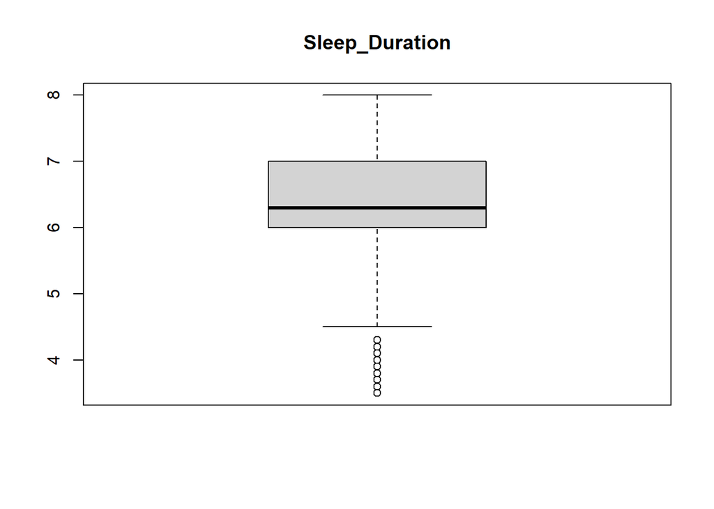

```r
columnas_numericas <- c("Age", "Sleep_Duration", "Sleep_Quality", "Physical_Activity",
                        "Screen_Time", "Caffeine_Intake", "Alcohol_Intake",
                        "Work_Hours", "Travel_Time", "Social_Interactions",
                        "Blood_Pressure", "Cholesterol_Level", "Blood_Sugar_Level")

boxplot(Sleep_Duration, main = "Sleep_Duration")
```

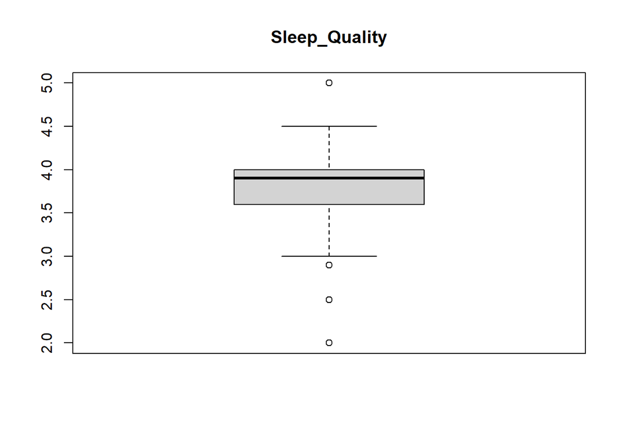

```r
boxplot(Sleep_Quality, main = "Sleep_Quality")
```

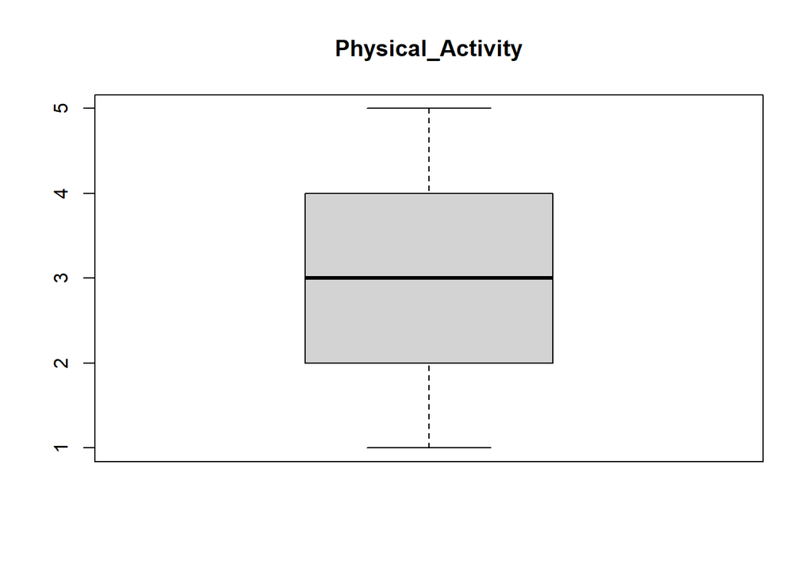

```r
boxplot(Physical_Activity, main = "Physical_Activity") # no
```

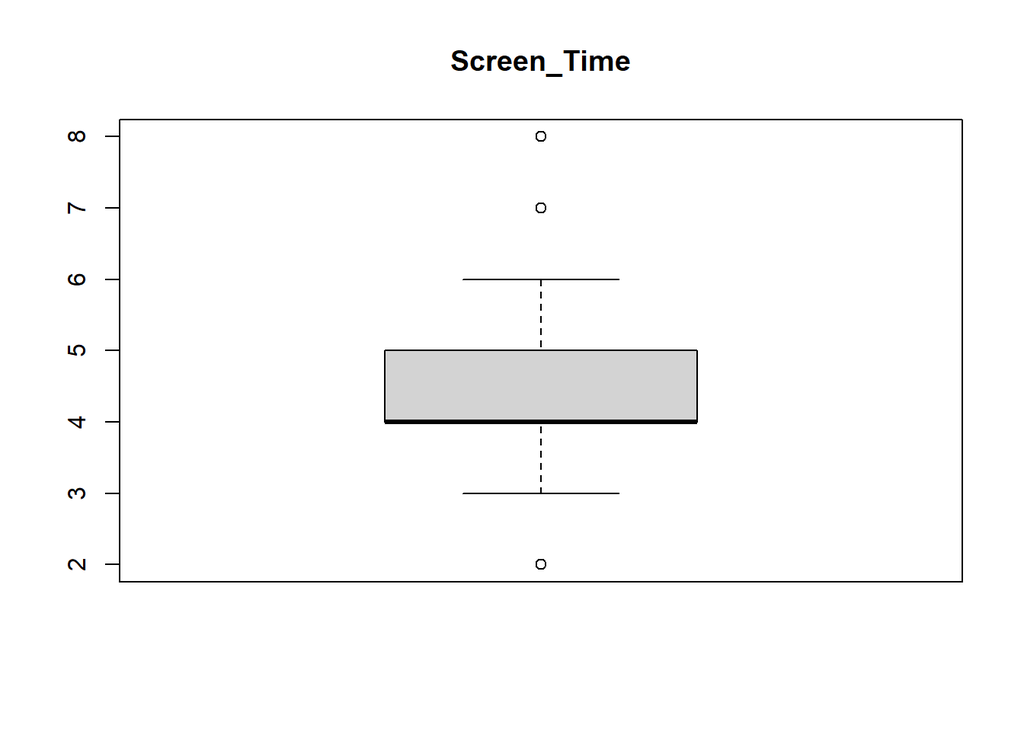

```r
boxplot(Screen_Time, main = "Screen_Time")
```

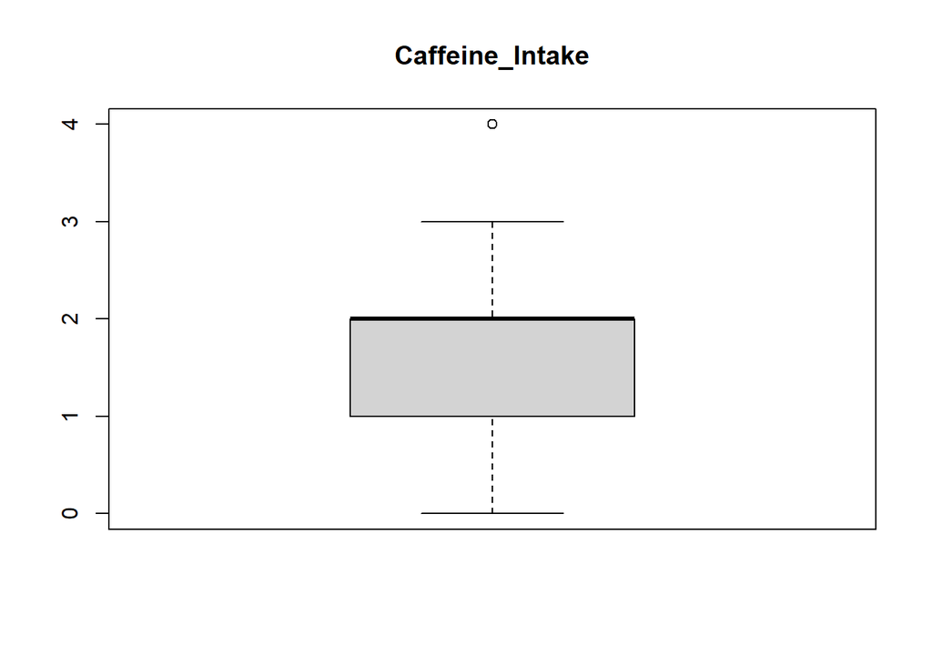

```r
boxplot(Caffeine_Intake, main = "Caffeine_Intake")
```

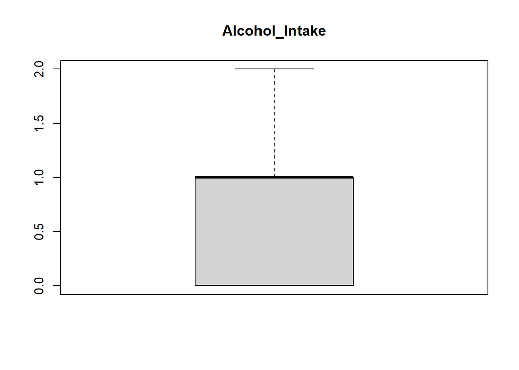

```r
boxplot(Alcohol_Intake, main = "Alcohol_Intake") # no
```

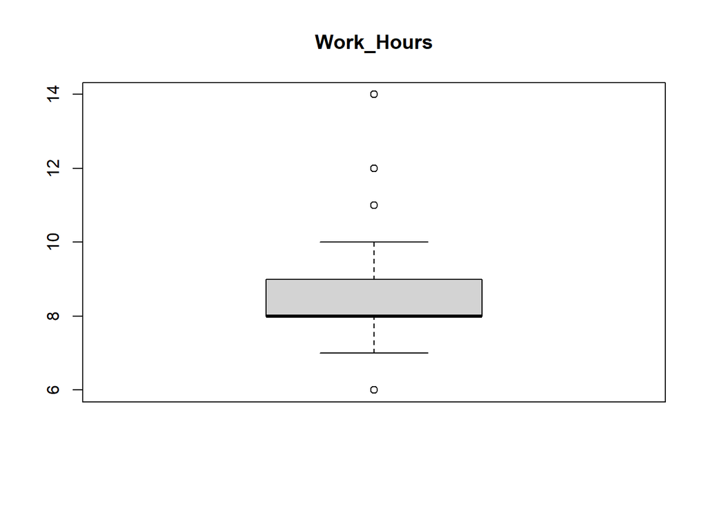

```r
boxplot(Work_Hours, main = "Work_Hours")
```

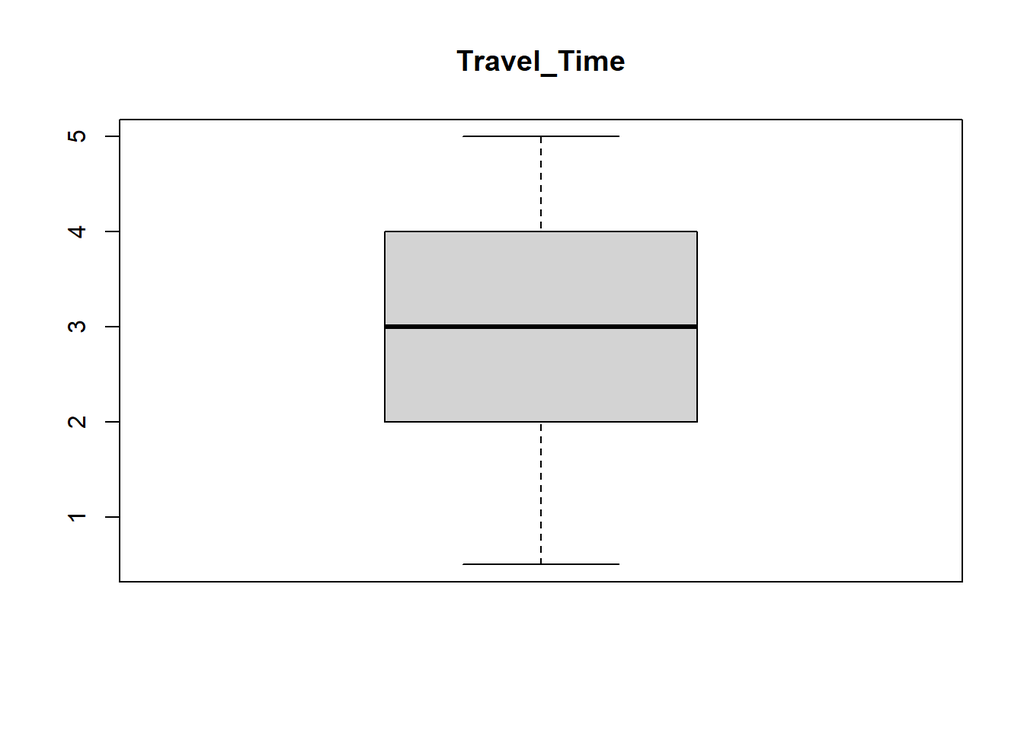

```r
boxplot(Travel_Time, main = "Travel_Time") # no
```

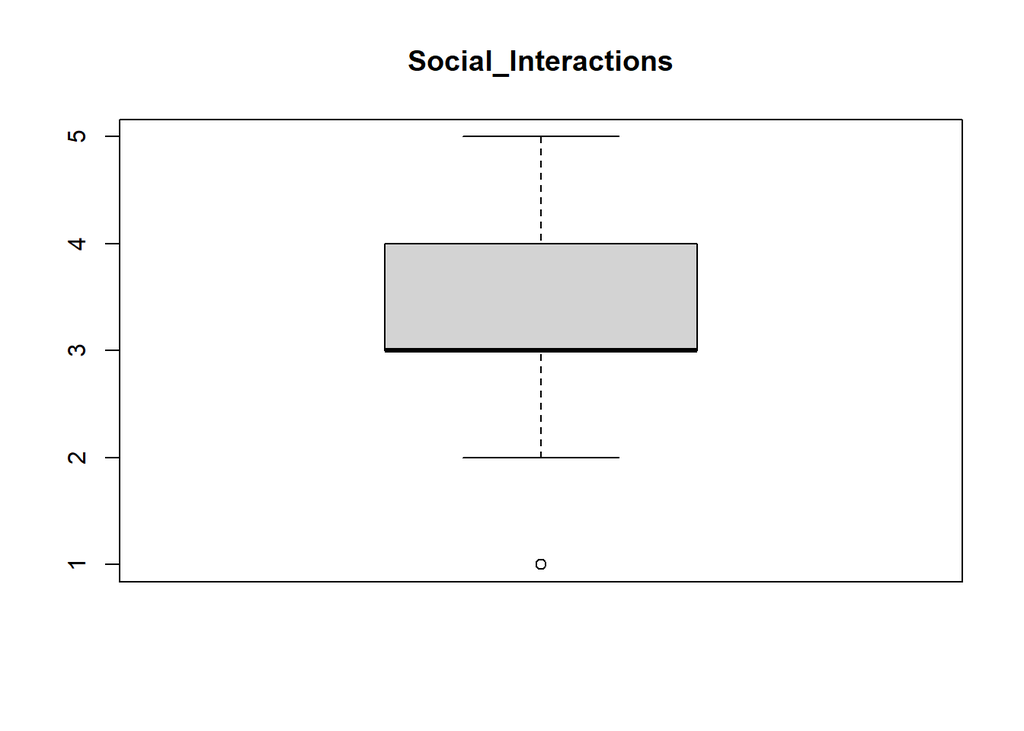

```r
boxplot(Social_Interactions, main = "Social_Interactions")
```

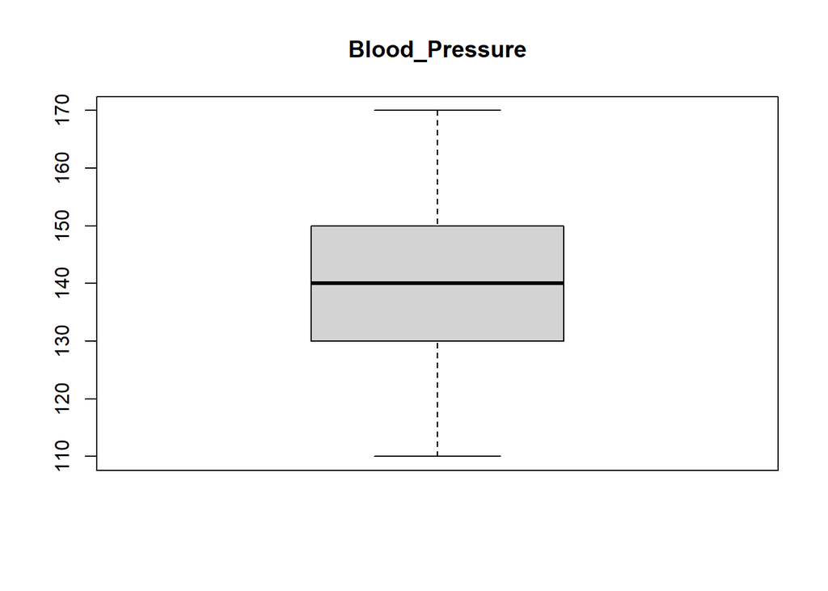

```r
boxplot(Blood_Pressure, main = "Blood_Pressure") # no
```

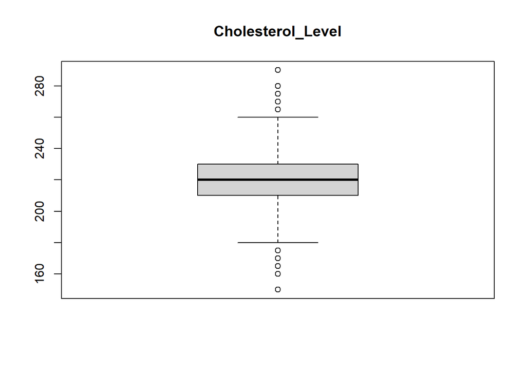

```r
boxplot(Cholesterol_Level, main = "Cholesterol_Level")
```

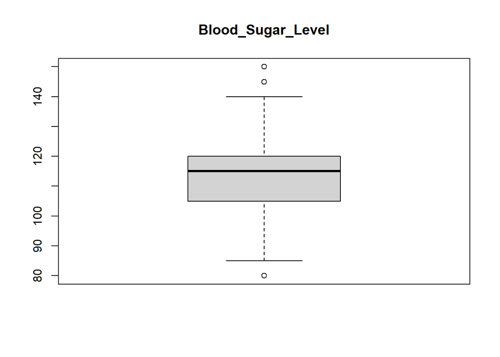

```r
boxplot(Blood_Sugar_Level, main = "Blood_Sugar_Level")
```

```r
columnas_con_outliers <- c("Sleep_Duration", "Sleep_Quality", "Screen_Time",
                           "Caffeine_Intake", "Work_Hours", "Social_Interactions",
                        "Cholesterol_Level", "Blood_Sugar_Level")

eliminar_outliers_pct <- function(df, columna, porcentaje = 0.05) {
  p_inf <- porcentaje / 2
  p_sup <- 1 - p_inf
  limites <- quantile(df[[columna]], probs = c(p_inf, p_sup), na.rm = TRUE)

  df_filtrado <- df[df[[columna]] >= limites[1] & df[[columna]] <= limites[2], ]
  return(df_filtrado)
}

for (col in columnas_con_outliers) {
  df <- eliminar_outliers_pct(df, col, porcentaje = 0.05)
}
```

# 3. Exploración y análisis descriptivo del conjunto de datos

```r
stress_colors <- c("Low" = "#7FC8A9","Medium" = "#F2D388", "High" = "#DE6B6B")
```

## 3.1. Distribución de los Niveles de Estrés

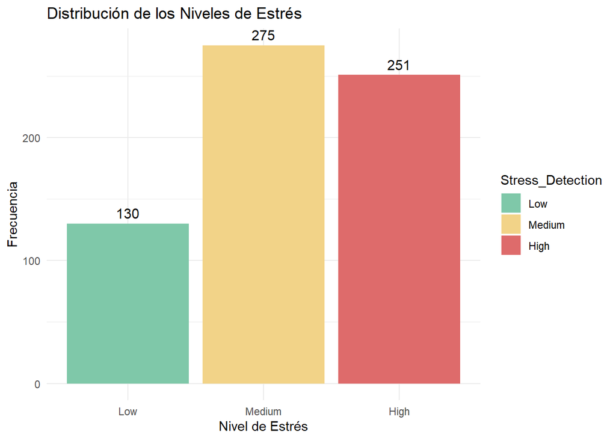

```r
ggplot(df, aes(x = Stress_Detection)) +
  geom_bar(aes(fill = Stress_Detection)) +
  geom_text(stat = "count", aes(label = after_stat(count)), vjust = -0.5, size = 4) +
  scale_fill_manual(values = stress_colors) +
  labs(title = "Distribución de los Niveles de Estrés",
       x = "Nivel de Estrés",
       y = "Frecuencia") +
  theme_minimal()
```

## 3.2. Distribuciones de los Niveles de Estrés de cada variable según tipo

### 3.2.1. Gráficos de Bienestar

```r
wellbeing_vars <- c("Age", "Sleep_Duration", "Sleep_Quality", "Caffeine_Intake", "Alcohol_Intake", "Blood_Pressure", "Cholesterol_Level", "Blood_Sugar_Level")

# Gráficos para las variables de bienestar o salud (variables numéricas)
wellbeing_plots <- list()

titles <- c("Edad", "Duración del Sueño", "Calidad del Sueño", "Consumo de Cafeína", "Consumo de Alcohol", "Presión Arterial", "Nivel de Colesterol", "Nivel de Azúcar en Sangre")

for (i in 1:length(wellbeing_vars)) {
  var <- wellbeing_vars[i]
  p <- ggplot(df, aes_string(x = "Stress_Detection", y = var, fill = "Stress_Detection")) +
    geom_boxplot() +
    scale_fill_manual(values = stress_colors) +
    labs(title = paste("Distribución de", titles[i], "por nivel de estrés"),
         x = "Nivel de Estrés", y = titles[i]) +
    theme_minimal() +
    theme(legend.position = "none")
  wellbeing_plots[[var]] <- p
}
```

### 3.2.2. Gráficos de Estilo de Vida

```r
lifestyle_vars <- c("Work_Hours", "Screen_Time", "Social_Interactions", "Travel_Time",
                    "Meditation_Practice", "Smoking_Habit", "Exercise_Type")

lifestyle_plots <- list()

lifestyle_titles <- c("Horas de Trabajo", "Tiempo en Pantalla", "Interacciones Sociales", "Tiempo de Viaje",
                      "Práctica de Meditación", "Hábito de Fumar", "Tipo de Ejercicio")

for (i in 1:length(lifestyle_vars)) {
  var <- lifestyle_vars[i]
  if (var %in% c("Work_Hours", "Screen_Time", "Social_Interactions", "Travel_Time")) {
    p <- ggplot(df, aes_string(x = "Stress_Detection", y = var, fill = "Stress_Detection")) +
      geom_boxplot() +
      scale_fill_manual(values = stress_colors) +
      labs(title = paste("Distribución de", lifestyle_titles[i], "por nivel de estrés"),
           x = "Nivel de Estrés", y = lifestyle_titles[i]) +
      theme_minimal() +
      theme(legend.position = "none")
    lifestyle_plots[[var]] <- p
  } else {
    p <- ggplot(df, aes_string(x = var, fill = "Stress_Detection")) +
      geom_bar(position = "fill") +
      scale_fill_manual(values = stress_colors) +
      labs(title = paste("Distribución de", lifestyle_titles[i], "por nivel de estrés"),
           x = lifestyle_titles[i], y = "Proporción") +
      theme_minimal() +
      theme(legend.position = "none")
    lifestyle_plots[[var]] <- p
  }
}
```

### 3.2.3. Gráficos de Variables Demográficas

```r
# Variables demográficas (categóricas)
demographic_vars <- c("Gender", "Marital_Status")

demographic_plots <- list()

demographic_titles <- c("Género", "Estado Civil")

for (i in 1:length(demographic_vars)) {
  var <- demographic_vars[i]
  p <- ggplot(df, aes_string(x = var, fill = "Stress_Detection")) +
    geom_bar(position = "fill") +
    scale_fill_manual(values = stress_colors) +
    labs(title = paste("Distribución de", demographic_titles[i], "por nivel de estrés"),
         x = demographic_titles[i], y = "Proporción") +
    theme_minimal() +
    theme(legend.position = "none")
  demographic_plots[[var]] <- p
}
```

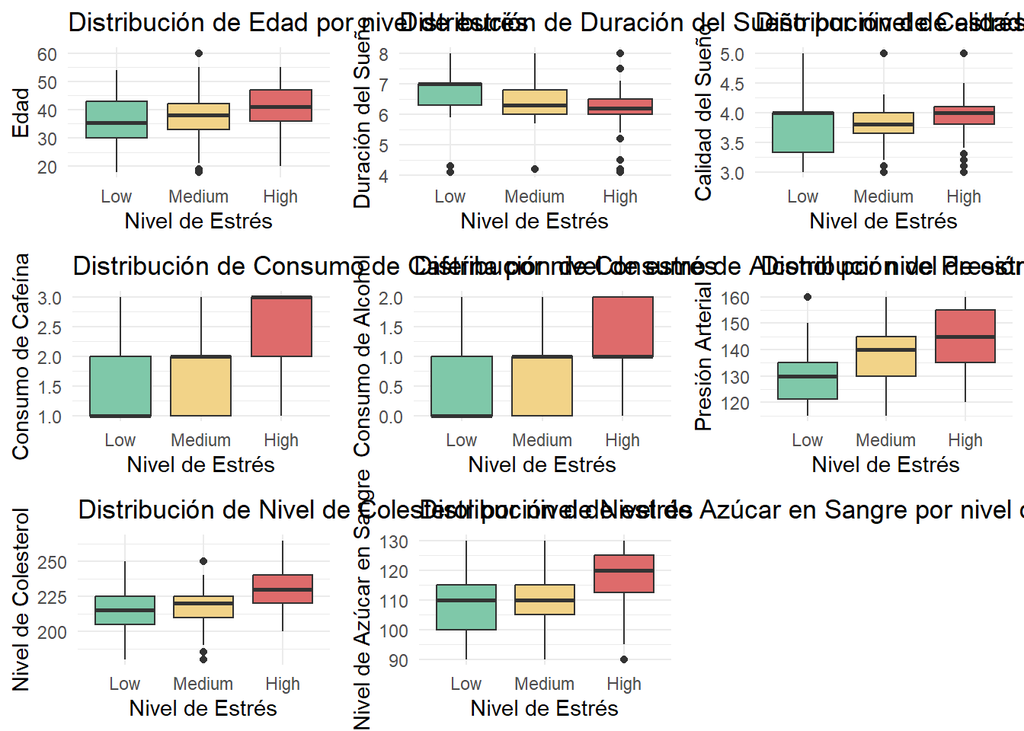

```r
# Organizar los gráficos en grids
# 1. Variables de bienestar o salud
wellbeing_grid <- grid.arrange(grobs = wellbeing_plots, ncol = 3)
```

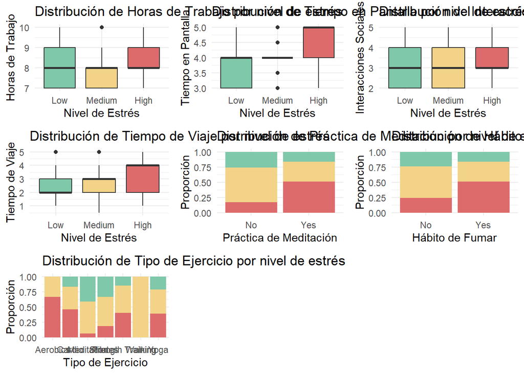

```r
# 2. Variables de actividad y estilo de vida
lifestyle_grid <- grid.arrange(grobs = lifestyle_plots, ncol = 3)
```

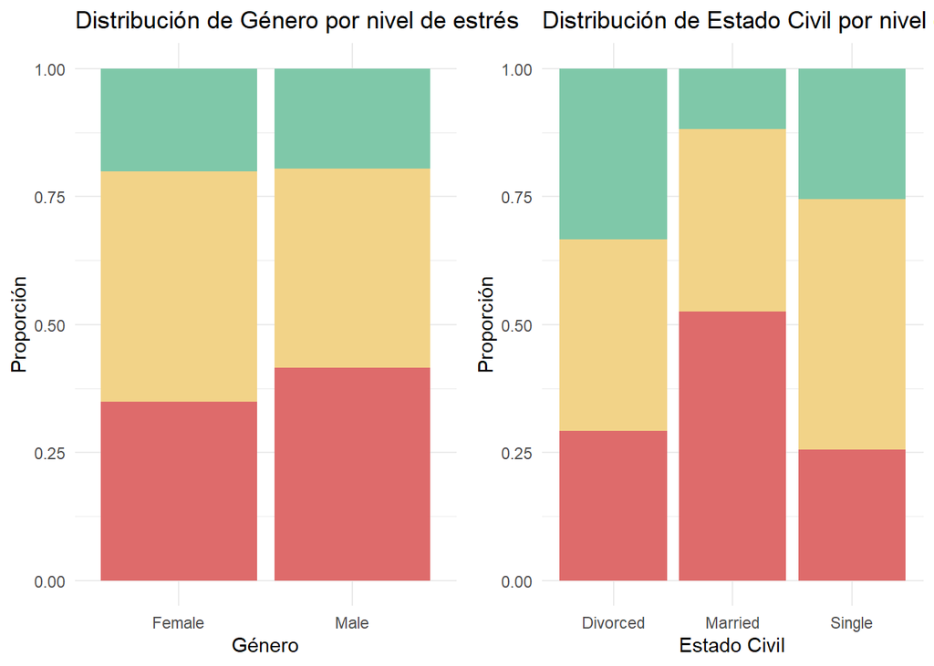

```r
# 3. Variables demográficas
demographic_grid <- grid.arrange(grobs = demographic_plots, ncol = 2)
```

## 3.3. Distribución de Edad según Nivel de Estrés

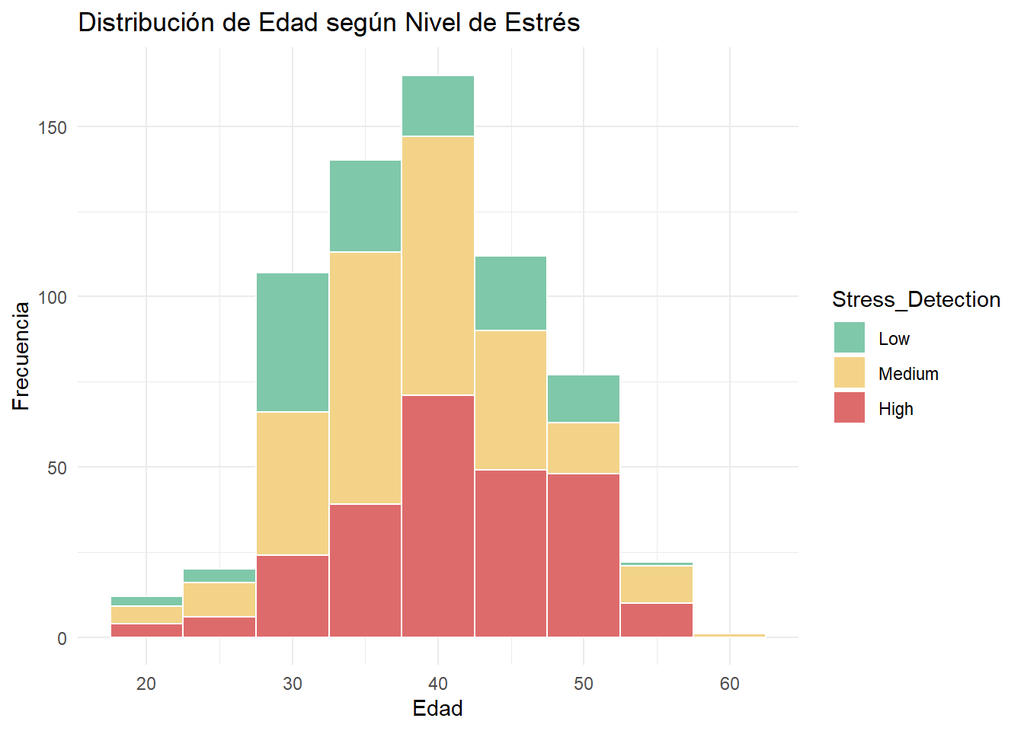

```r
ggplot(df, aes(x = Age, fill = Stress_Detection)) +
  geom_histogram(binwidth = 5, color = "white") +
  scale_fill_manual(values = stress_colors) +
  labs(title = "Distribución de Edad según Nivel de Estrés",
       x = "Edad", y = "Frecuencia") +
  theme_minimal()
```

## 3.4. Horas de sueño y nivel de estrés

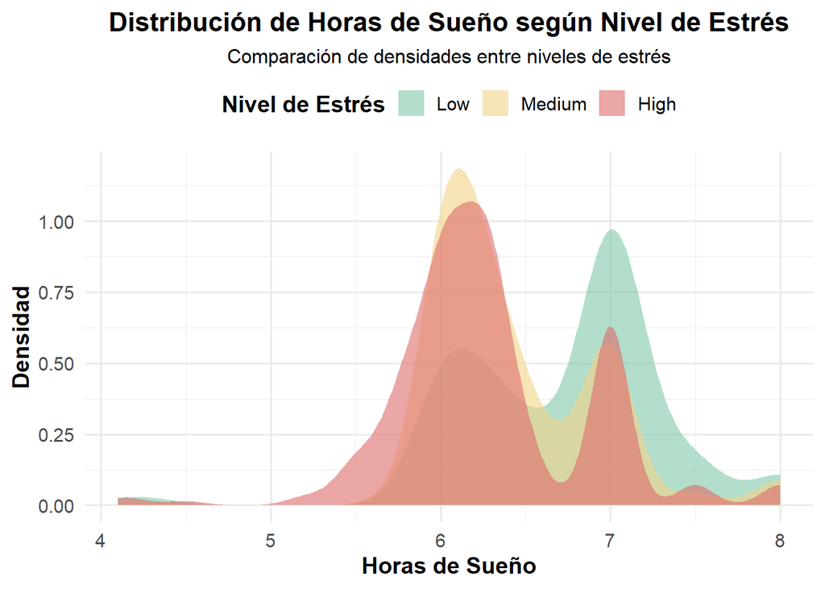

```r
ggplot(df, aes(x = Sleep_Duration, fill = Stress_Detection)) +
  geom_density(alpha = 0.6, color = NA) +
  scale_fill_manual(values = stress_colors) +
  labs(
    title = "Distribución de Horas de Sueño según Nivel de Estrés",
    subtitle = "Comparación de densidades entre niveles de estrés",
    x = "Horas de Sueño",
    y = "Densidad",
    fill = "Nivel de Estrés"
  ) +
  theme_minimal(base_size = 14) +
  theme(
    plot.title = element_text(hjust = 0.5, face = "bold", size = 16),
    plot.subtitle = element_text(hjust = 0.5, size = 12),
    axis.title = element_text(face = "bold"),
    legend.position = "top",
    legend.title = element_text(face = "bold")
  )
```

## 3.5. Relación entre el Tiempo de pantalla y el nivel de estrés

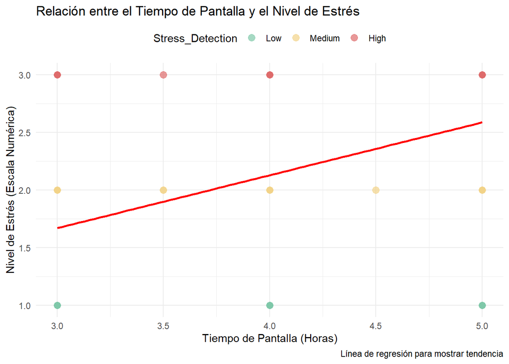

```r
ggplot(df, aes(x = Screen_Time, y = Stress_Detection_Numeric)) +
  geom_point(aes(color = Stress_Detection), alpha = 0.7, size = 3) +
  geom_smooth(method = "lm", se = FALSE, color = "red") +  # Ajuste de la línea de regresión
  scale_color_manual(values = stress_colors) +
  labs(
    title = "Relación entre el Tiempo de Pantalla y el Nivel de Estrés",
    x = "Tiempo de Pantalla (Horas)",
    y = "Nivel de Estrés (Escala Numérica)",
    caption = "Línea de regresión para mostrar tendencia"
  ) +
  theme_minimal() +
  theme(legend.position = "top")
```

## 3.6. Impacto del Consumo de Alcohol en el Nivel de Estrés

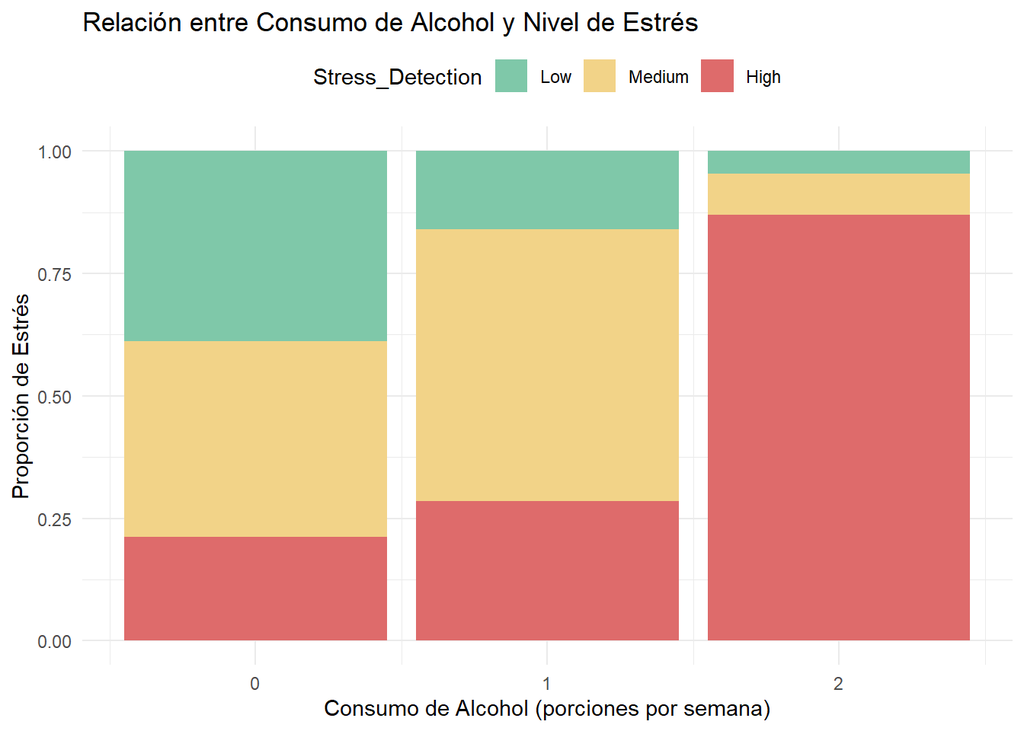

```r
ggplot(df, aes(x = Alcohol_Intake, fill = Stress_Detection)) +
  geom_bar(position = "fill", stat = "count") +
  scale_fill_manual(values = stress_colors) +
  labs(title = "Relación entre Consumo de Alcohol y Nivel de Estrés",
       x = "Consumo de Alcohol (porciones por semana)", y = "Proporción de Estrés") +
  theme_minimal() +
  theme(legend.position = "top")
```

## 3.7. Distribución del Nivel de Estrés por Hábito de Fumar

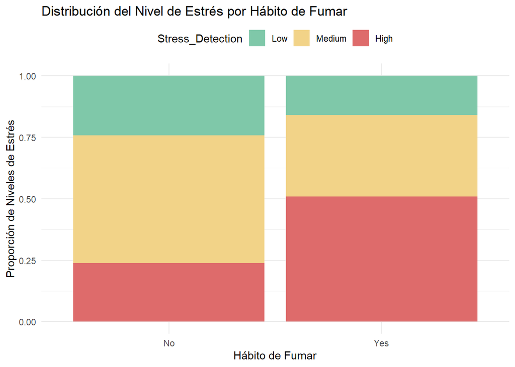

```r
ggplot(df, aes(x = Smoking_Habit, fill = Stress_Detection)) +
  geom_bar(position = "fill") +
  scale_fill_manual(values = stress_colors) +
  labs(
    title = "Distribución del Nivel de Estrés por Hábito de Fumar",
    x = "Hábito de Fumar",
    y = "Proporción de Niveles de Estrés"
  ) +
  theme_minimal() +
  theme(legend.position = "top")
```

## 3.8. Comparación de Nivel de Estrés por Estado Civil

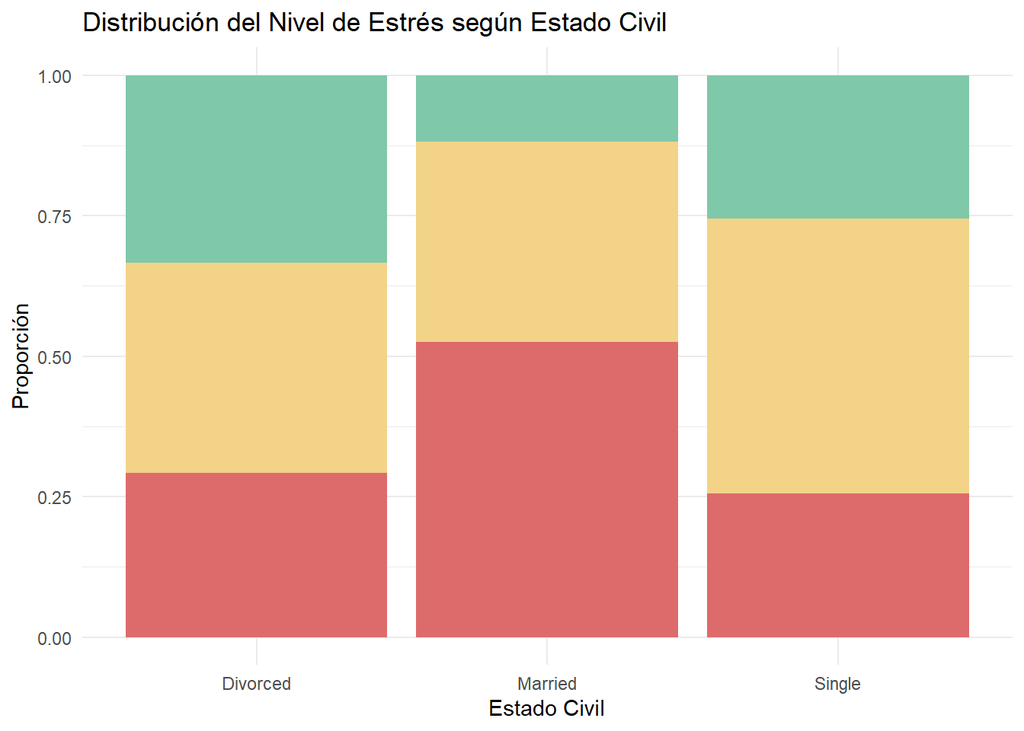

```r
ggplot(df, aes(x = Marital_Status, fill = Stress_Detection)) +
  geom_bar(position = "fill") +
  scale_fill_manual(values = stress_colors) +
  labs(title = "Distribución del Nivel de Estrés según Estado Civil",
       x = "Estado Civil", y = "Proporción") +
  theme_minimal() +
  theme(legend.position = "none")
```

## 3.9. Relación entre las horas de trabajo y el estrés

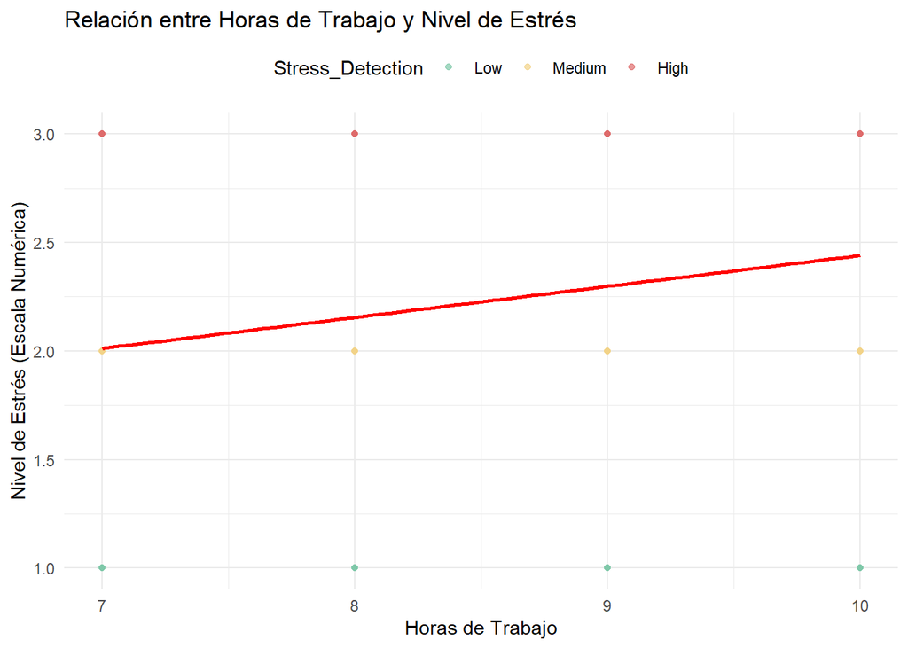

```r
ggplot(df, aes(x = Work_Hours, y = Stress_Detection_Numeric)) +
  geom_point(aes(color = Stress_Detection), alpha = 0.7) +
  geom_smooth(method = "lm", se = FALSE, color = "red") +
  scale_color_manual(values = stress_colors) +
  labs(
    title = "Relación entre Horas de Trabajo y Nivel de Estrés",
    x = "Horas de Trabajo",
    y = "Nivel de Estrés (Escala Numérica)"
  ) +
  theme_minimal() +
  theme(legend.position = "top")
```

## 3.10. Relación entre indicadores de salud física y estrés

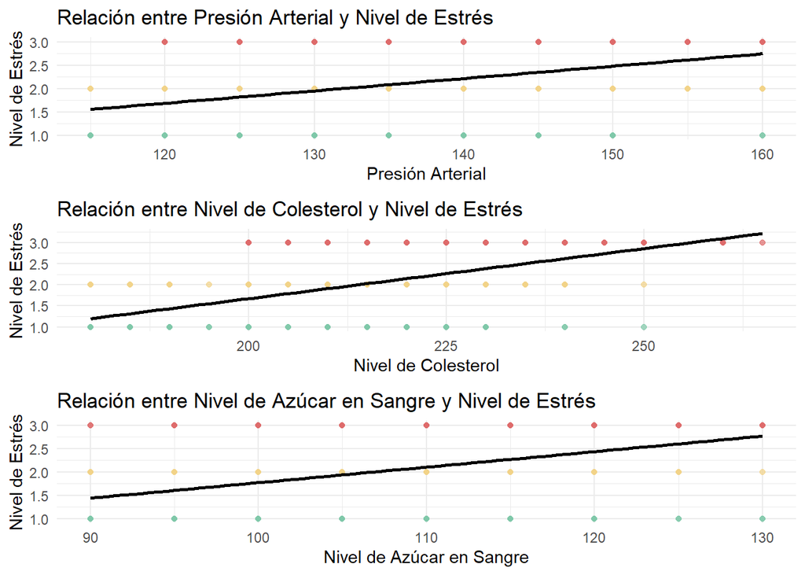

```r
regression_plots <- list()

# Gráfico para Blood Pressure
p1 <- ggplot(df, aes(x = Blood_Pressure, y = Stress_Detection_Numeric)) +
  geom_point(aes(color = Stress_Detection), alpha = 0.7) +
  geom_smooth(method = "lm", se = FALSE, color = "black") +
  scale_color_manual(values = stress_colors) +
  labs(title = "Relación entre Presión Arterial y Nivel de Estrés",
       x = "Presión Arterial", y = "Nivel de Estrés") +
  theme_minimal() +
  theme(legend.position = "none")

# Gráfico para Cholesterol Level
p2 <- ggplot(df, aes(x = Cholesterol_Level, y = Stress_Detection_Numeric)) +
  geom_point(aes(color = Stress_Detection), alpha = 0.7) +
  geom_smooth(method = "lm", se = FALSE, color = "black") +
  scale_color_manual(values = stress_colors) +
  labs(title = "Relación entre Nivel de Colesterol y Nivel de Estrés",
       x = "Nivel de Colesterol", y = "Nivel de Estrés") +
  theme_minimal() +
  theme(legend.position = "none")

# Gráfico para Blood Sugar Level
p3 <- ggplot(df, aes(x = Blood_Sugar_Level, y = Stress_Detection_Numeric)) +
  geom_point(aes(color = Stress_Detection), alpha = 0.7) +
  geom_smooth(method = "lm", se = FALSE, color = "black") +
  scale_color_manual(values = stress_colors) +
  labs(title = "Relación entre Nivel de Azúcar en Sangre y Nivel de Estrés",
       x = "Nivel de Azúcar en Sangre", y = "Nivel de Estrés") +
  theme_minimal() +
  theme(legend.position = "none")

# Agregar los gráficos a la lista
regression_plots[["Blood_Pressure"]] <- p1
regression_plots[["Cholesterol_Level"]] <- p2
regression_plots[["Blood_Sugar_Level"]] <- p3

# Organizar los gráficos en un grid de 3 filas
grid.arrange(grobs = regression_plots, ncol = 1)
```

## 3.11. Mapa de correlación entre variables numéricas

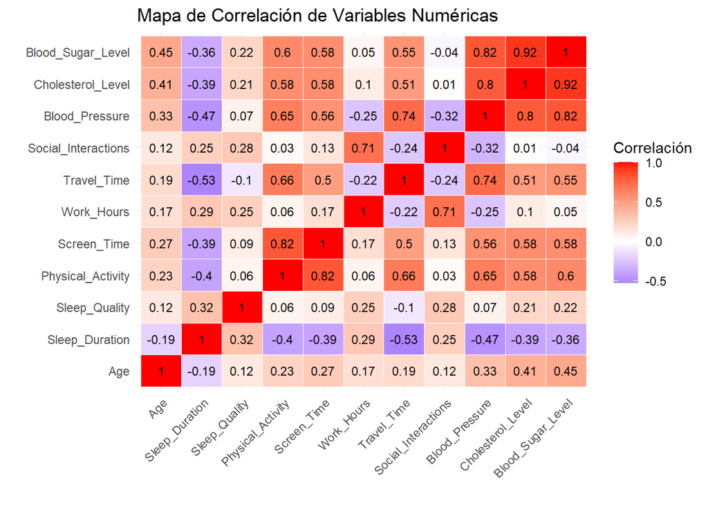

```r
numeric_df <- df %>%
  select(Age, Sleep_Duration, Sleep_Quality, Physical_Activity,
         Screen_Time, Work_Hours, Travel_Time, Social_Interactions,
         Blood_Pressure, Cholesterol_Level, Blood_Sugar_Level)

cor_matrix <- round(cor(numeric_df, use = "complete.obs"), 2)
melted_cor <- melt(cor_matrix)

ggplot(melted_cor, aes(Var1, Var2, fill = value)) +
  geom_tile(color = "white") +
  scale_fill_gradient2(low = "blue", mid = "white", high = "red", midpoint = 0,
                       name = "Correlación") +
  geom_text(aes(label = value), size = 3) +
  theme_minimal() +
  labs(title = "Mapa de Correlación de Variables Numéricas",
       x = "", y = "") +
  theme(axis.text.x = element_text(angle = 45, hjust = 1))
```

## 3.12. Influencia del Género y Estado Civil en los Niveles de Estrés

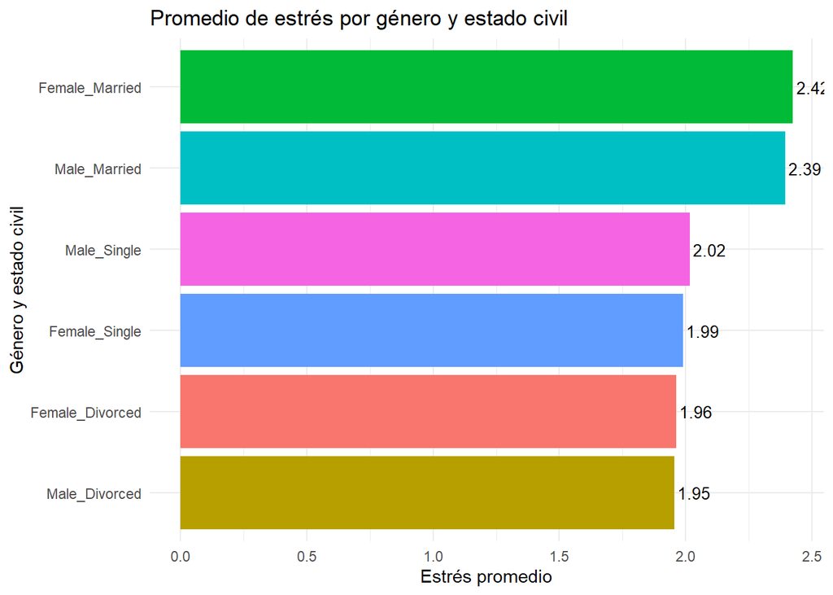

```r
df$Genero_Estado <- interaction(df$Gender, df$Marital_Status, sep = "_")

df %>%
  group_by(Genero_Estado) %>%
  summarise(Promedio_Estres = mean(Stress_Detection_Numeric)) %>%
  ggplot(aes(x = reorder(Genero_Estado, Promedio_Estres),
             y = Promedio_Estres, fill = Genero_Estado)) +
  geom_col() +
  geom_text(aes(label = round(Promedio_Estres, 2)),
            hjust = -0.1, size = 3.5) +
  coord_flip() +
  labs(title = "Promedio de estrés por género y estado civil",
       x = "Género y estado civil",
       y = "Estrés promedio") +
  theme_minimal() +
  theme(legend.position = "none")
```

# 4. Modelado Predictivo (Aprendizaje Supervisado)

## 4.1. Partición de datos

```r
# Semilla para reproducibilidad
set.seed(123)

# Crear índices para la partición (80% entrenamiento, 20% prueba)
train_index <- createDataPartition(df$Stress_Detection, p = 0.8, list = FALSE)

# Crear conjuntos de entrenamiento y prueba
train_data <- df[train_index, ]
test_data <- df[-train_index, ]

# Verificar proporciones
prop.table(table(train_data$Stress_Detection))
```

```
##
##       Low    Medium      High
## 0.1980952 0.4190476 0.3828571
```

```r
prop.table(table(test_data$Stress_Detection))
```

```
##
##       Low    Medium      High
## 0.1984733 0.4198473 0.3816794
```

## 4.2. Preprocesamiento Eficiente

```r
library(recipes)
# Crear receta de preprocesamiento
recipe_spec <- recipe(Stress_Detection ~ ., data = train_data) %>%
  step_rm(Stress_Detection_Numeric) %>%  # Eliminar la versión numérica
  step_normalize(all_numeric()) %>%      # Estandarizar variables numéricas
  step_dummy(all_nominal(), -all_outcomes()) %>%  # Convertir categóricas a dummy
  step_zv(all_predictors())              # Eliminar predictores con varianza cero

# Preparar la receta (calcula los parámetros de transformación)
prepped_recipe <- prep(recipe_spec, training = train_data)

# Aplicar a los conjuntos de entrenamiento y prueba
train_processed <- bake(prepped_recipe, new_data = train_data)
test_processed <- bake(prepped_recipe, new_data = test_data)
```

## 4.3. Random Forest

```r
# Configurar control de entrenamiento
ctrl_rf <- trainControl(method = "cv", number = 3, verboseIter = FALSE)

# Grid de parámetros reducido
rf_grid <- expand.grid(
  mtry = c(3, 5, 7),
  splitrule = "gini",
  min.node.size = c(5, 10)  # Nodos más grandes para árboles más pequeños
)

# Entrenar modelo con menos árboles
rf_model <- train(
  Stress_Detection ~ .,
  data = train_processed,
  method = "ranger",
  trControl = ctrl_rf,
  tuneGrid = rf_grid,
  num.trees = 100,
  importance = "permutation"  # Para obtener importancia de variables
)

# Evaluación
rf_pred <- predict(rf_model, newdata = test_processed)
confusionMatrix(rf_pred, test_processed$Stress_Detection)
```

```
## Confusion Matrix and Statistics
##
##           Reference
## Prediction Low Medium High
##     Low      9      3    0
##     Medium  14     41   18
##     High     3     11   32
##
## Overall Statistics
##
##                Accuracy : 0.626
##                  95% CI : (0.5372, 0.7089)
##     No Information Rate : 0.4198
##     P-Value [Acc > NIR] : 1.618e-06
##
##                   Kappa : 0.3906
##
##  Mcnemar's Test P-Value : 0.008073
##
## Statistics by Class:
##
##                      Class: Low Class: Medium Class: High
## Sensitivity              0.3462        0.7455      0.6400
## Specificity              0.9714        0.5789      0.8272
## Pos Pred Value           0.7500        0.5616      0.6957
## Neg Pred Value           0.8571        0.7586      0.7882
## Prevalence               0.1985        0.4198      0.3817
## Detection Rate           0.0687        0.3130      0.2443
## Detection Prevalence     0.0916        0.5573      0.3511
## Balanced Accuracy        0.6588        0.6622      0.7336
```

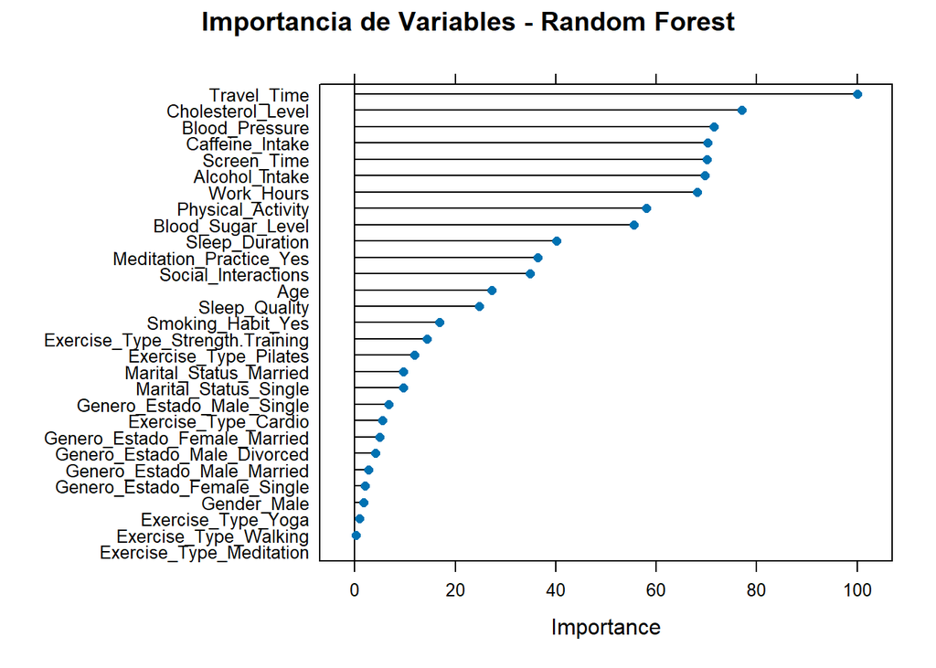

```r
# Importancia de variables
var_imp_rf <- varImp(rf_model)
plot(var_imp_rf, main = "Importancia de Variables - Random Forest")
```

# 5. Análisis No Supervisado con K-means y PCA

## 5.1. Normalización de los Datos Numéricos

Primero, estandarizamos las variables numéricas para que todas estén en la misma escala (media = 0, desviación estándar = 1). Esto es necesario porque variables como “Age” y “Cholesterol_Level” están en rangos muy diferentes.

```r
df_numeric <- df %>% select_if(is.numeric)
unsupervised_data <- scale(df_numeric)
```

## 5.2. Análisis de Componentes Principales (PCA)

Este método reduce la cantidad de variables y nos permite visualizar los datos en 2D.

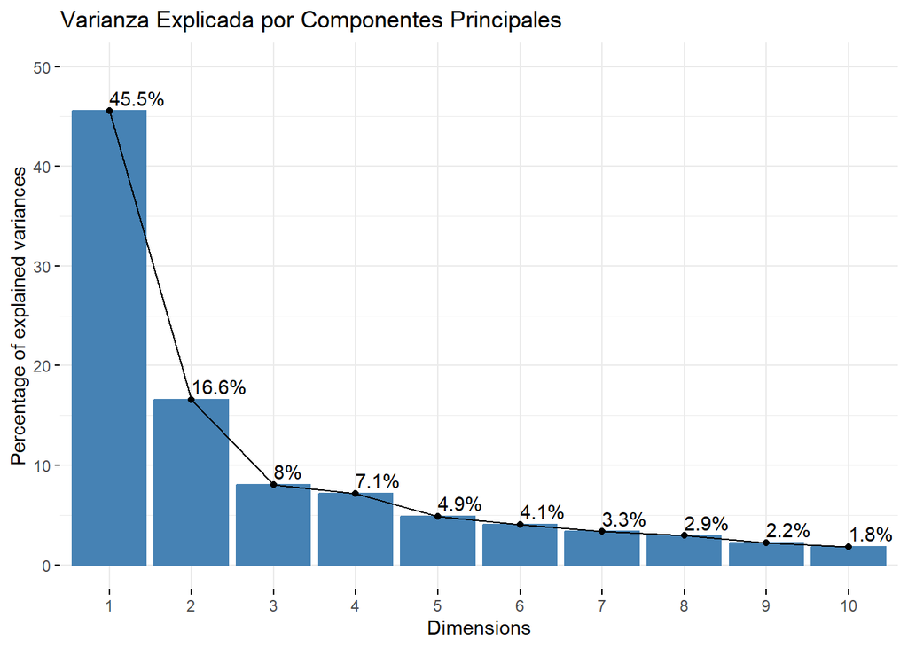

```r
pca <- prcomp(unsupervised_data, center = TRUE, scale. = TRUE)
fviz_eig(pca, addlabels = TRUE, ylim = c(0, 50), main = "Varianza Explicada por Componentes Principales")
```

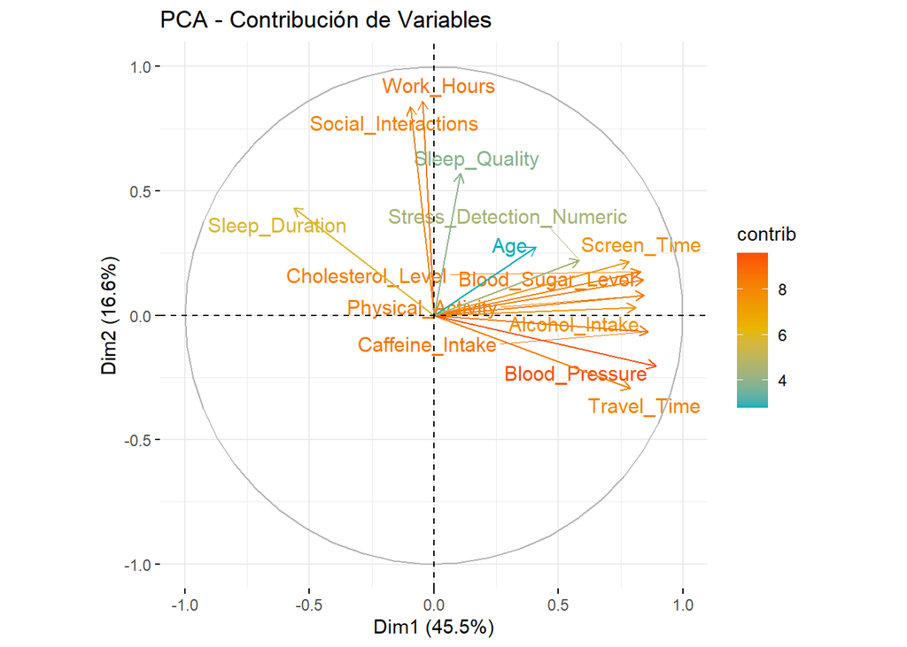

```r
fviz_pca_var(pca, col.var = "contrib",
             gradient.cols = c("#00AFBB", "#E7B800", "#FC4E07"),
             repel = TRUE) +
  labs(title = "PCA - Contribución de Variables")
```

**Interpretación:** Las primeras 2 o 3 componentes principales explican una buena parte de la variabilidad de los datos.

Esto nos da permiso de hacer gráficas bidimensionales sin perder demasiada información.

## 5.3. K-means Clustering

Primero, buscamos cuántos clusters (grupos) tiene sentido crear:

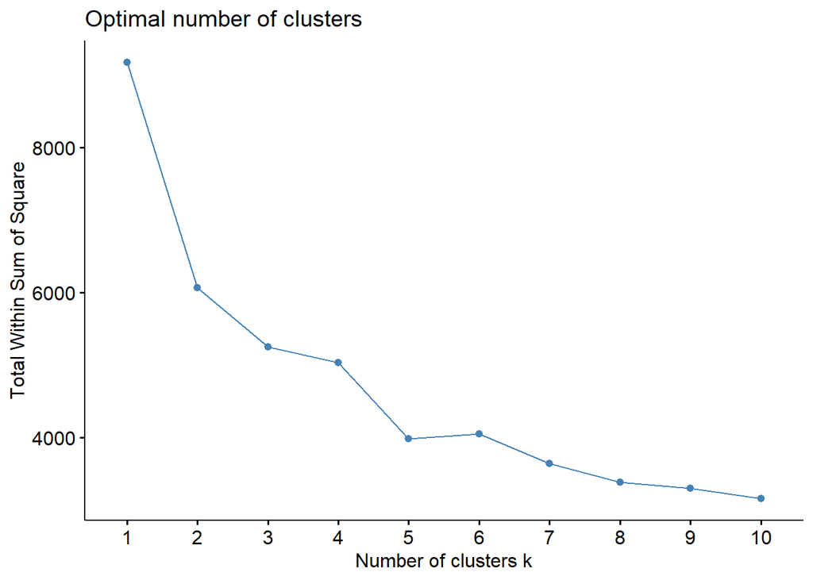

```r
fviz_nbclust(unsupervised_data, kmeans, method = "wss")
```

```r
set.seed(123)
kmeans_result <- kmeans(unsupervised_data, centers = 3, nstart = 25)
df$cluster <- as.factor(kmeans_result$cluster)
```

Ahora los visualizamos en 2D con PCA:

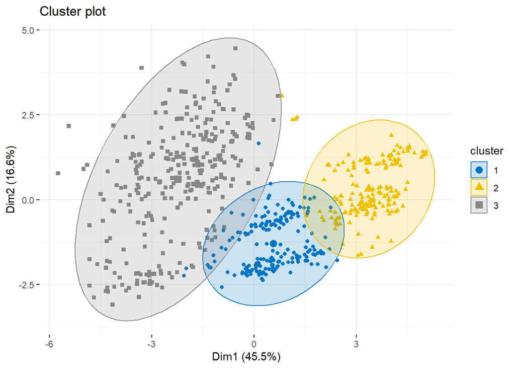

```r
fviz_cluster(kmeans_result, data = unsupervised_data,
             geom = "point", ellipse.type = "norm",
             palette = "jco", ggtheme = theme_minimal())
```